# Supervised Learning - Foundations Project: ReCell

# Dealing with missing values

```python
df.isnull().sum()
```

```
brand_name                 0
os                         0
screen_size                0
4g                         0
5g                         0
main_camera_mp           179
selfie_camera_mp           2
int_memory                 4
ram                        4
battery                    6
weight                     7
release_year               0
days_used                  0
normalized_used_price      0
normalized_new_price       0
device_age                 0
device_category_age        0
device_category            0
dtype: int64
```

```python
df1["main_camera_mp"] = df1["main_camera_mp"].fillna(value=df1.groupby(["brand_name","release_year"])["main_camera_mp"].transform("median")
)
df1["selfie_camera_mp"] = df1["selfie_camera_mp"].fillna(
    value=df1.groupby(["brand_name","release_year"])["selfie_camera_mp"].transform("median")
)
df1["int_memory"] = df1["int_memory"].fillna(
    value=df1.groupby(["brand_name","release_year"])["int_memory"].transform("median")
)
df1["ram"] = df1["ram"].fillna(
    value=df1.groupby(["brand_name","release_year"])["ram"].transform("median")
)
df1["battery"] = df1["battery"].fillna(
    value=df1.groupby(["brand_name","release_year"])["battery"].transform("median")
    )
df1["weight"] = df1["weight"].fillna(
    value=df1.groupby(["brand_name","release_year"])["weight"].transform("median"))
df1.isnull().sum()
```

```
brand_name                 0
os                         0
screen_size                0
4g                         0
5g                         0
main_camera_mp           179
selfie_camera_mp           2
int_memory                 0
ram                        0
battery                    6
weight                     7
release_year               0
days_used                  0
normalized_used_price      0
normalized_new_price       0
dtype: int64
```

```python
# Assuming df1 is your DataFrame

# Impute missing values using median grouped by "brand_name"
df1["main_camera_mp"] = df1["main_camera_mp"].fillna(value=df1.groupby("brand_name")["main_camera_mp"].transform("median"))
df1["selfie_camera_mp"] = df1["selfie_camera_mp"].fillna(value=df1.groupby("brand_name")["selfie_camera_mp"].transform("median"))
df1["int_memory"] = df1["int_memory"].fillna(value=df1.groupby("brand_name")["int_memory"].transform("median"))
df1["ram"] = df1["ram"].fillna(value=df1.groupby("brand_name")["ram"].transform("median"))
df1["battery"] = df1["battery"].fillna(value=df1.groupby("brand_name")["battery"].transform("median"))
df1["weight"] = df1["weight"].fillna(value=df1.groupby("brand_name")["weight"].transform("median"))

# Check for remaining missing values
df1.isnull().sum()
```

```
brand_name                0
os                        0
screen_size               0
4g                        0
5g                        0
main_camera_mp           10
selfie_camera_mp          0
int_memory                0
ram                       0
battery                   0
weight                    0
release_year              0
days_used                 0
normalized_used_price     0
normalized_new_price      0
dtype: int64
```

```python
df1["main_camera_mp"] = df1["main_camera_mp"].fillna(df1["main_camera_mp"].median()) ## impute the data with median

# checking for missing values
df1.isnull().sum() ## check missing values after imputing the above columns
```

```
brand_name               0
os                       0
screen_size              0
4g                       0
5g                       0
main_camera_mp           0
selfie_camera_mp         0
int_memory               0
ram                      0
battery                  0
weight                   0
release_year             0
days_used                0
normalized_used_price    0
normalized_new_price     0
dtype: int64
```

Missing values have been removed

# Outlier detection

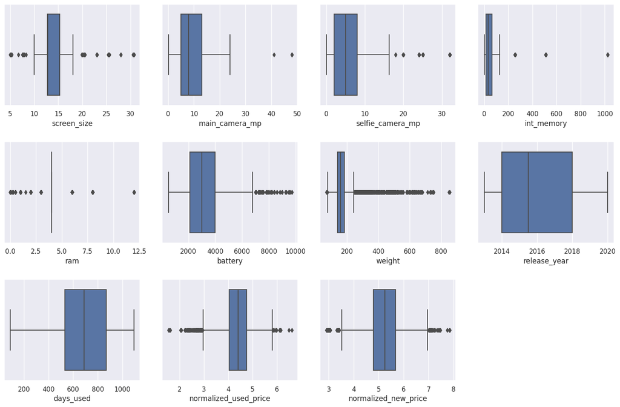

```python
# outlier detection using boxplot
num_cols = df1.select_dtypes(include=np.number).columns.tolist()

plt.figure(figsize=(15, 10))

for i, variable in enumerate(num_cols):
    plt.subplot(3, 4, i + 1)
    sns.boxplot(data=df1, x=variable)
    plt.tight_layout(pad=2)

plt.show()
```

there are quite a few outliers in battery,normalized_used_price,normalized_new_price,ram , screen size,selfie_cam_mp,weight,Main_camera_mp

```python
selfie_outliers=df1[df1["selfie_camera_mp"]>25]
df1[df1["selfie_camera_mp"]>25].describe()
```

|  | screen_size | main_camera_mp | selfie_camera_mp | int_memory | ram | battery | weight | release_year | days_used | normalized_used_price | normalized_new_price |
| --- | --- | --- | --- | --- | --- | --- | --- | --- | --- | --- | --- |
| count | 94.000000 | 94.000000 | 94.0 | 94.000000 | 94.000000 | 94.000000 | 94.000000 | 94.000000 | 94.000000 | 94.000000 | 94.000000 |
| mean | 15.864149 | 11.627660 | 32.0 | 133.446809 | 6.638298 | 4089.361702 | 181.582979 | 2019.372340 | 295.053191 | 5.162726 | 5.869460 |
| std | 0.487470 | 2.006624 | 0.0 | 47.542085 | 1.836611 | 458.180268 | 13.128371 | 0.486021 | 105.762095 | 0.319924 | 0.471766 |
| min | 15.270000 | 8.000000 | 32.0 | 64.000000 | 4.000000 | 3340.000000 | 152.900000 | 2019.000000 | 91.000000 | 3.847804 | 4.925077 |
| 25% | 15.370000 | 10.500000 | 32.0 | 128.000000 | 6.000000 | 4000.000000 | 172.450000 | 2019.000000 | 213.500000 | 5.025693 | 5.596531 |
| 50% | 15.900000 | 13.000000 | 32.0 | 128.000000 | 6.000000 | 4000.000000 | 180.000000 | 2019.000000 | 282.500000 | 5.179872 | 5.884728 |
| 75% | 16.230000 | 13.000000 | 32.0 | 128.000000 | 8.000000 | 4315.000000 | 186.000000 | 2020.000000 | 367.250000 | 5.360210 | 6.090471 |
| max | 16.940000 | 13.000000 | 32.0 | 256.000000 | 12.000000 | 6000.000000 | 217.000000 | 2020.000000 | 520.000000 | 5.792038 | 7.003347 |

### Observation

```python
df2=df1.copy()
```

```python
df2.drop(selfie_outliers.index,axis=0, inplace=True) # dropping the selfie_camera_mp outliers as there is no meanningful values.
```

```python
df2.selfie_camera_mp.describe() # checking "selfie_camera" again using describe()
```

```
count    3360.000000
mean        5.843214
std         5.593992
min         0.000000
25%         2.000000
50%         5.000000
75%         8.000000
max        25.000000
Name: selfie_camera_mp, dtype: float64
```

Rest of the outliers seem to be valid values

```python
small_constant = 1e-10  # or any small positive value you choose
df2["weight_log"] = np.log(df2["weight"] + small_constant)
```

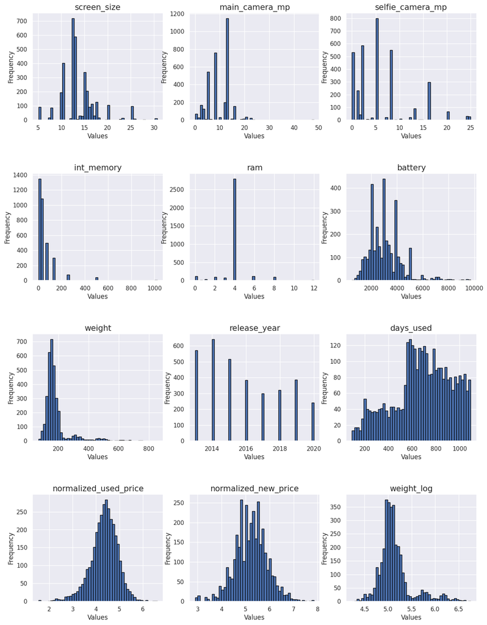

```python
import matplotlib.pyplot as plt
import math

# Assuming num_cols is a list of numerical column names
num_cols = df2.select_dtypes(include='number').columns.tolist()

# Calculate the number of rows and columns needed for the subplots
num_rows = math.ceil(len(num_cols) / 3)
num_columns = 3

# Create subplots
fig, axes = plt.subplots(num_rows, num_columns, figsize=(15, 5 * num_rows))
fig.subplots_adjust(hspace=0.5)

# Plot histograms
for i, col in enumerate(num_cols):
    row_idx = i // num_columns
    col_idx = i % num_columns
    axes[row_idx, col_idx].hist(df2[col], bins=50, edgecolor='black')
    axes[row_idx, col_idx].set_title(col, fontsize=15)
    axes[row_idx, col_idx].set_xlabel("Values")
    axes[row_idx, col_idx].set_ylabel("Frequency")

# Hide empty subplots (if any)
for i in range(len(num_cols), num_rows * num_columns):
    row_idx = i // num_columns
    col_idx = i % num_columns
    fig.delaxes(axes[row_idx, col_idx])

plt.show()
```

weight and int_memory seem to be right skewed

## EDA

- It is a good idea to explore the data once again after manipulating it.

```python
df3=df2.copy()
df3["device_category"] = pd.cut(
    x=df.normalized_new_price,
    bins=[-np.infty, 4.5, 6.5, np.infty],
    labels=["Budget", "Mid_ranger", "Premium"],
)

df3["device_category"].value_counts()
# categorizing phones accoring to prices
```

```
Mid_ranger    2820
Budget         433
Premium        107
Name: device_category, dtype: int64
```

```python
df3.columns
```

```
Index(['brand_name', 'os', 'screen_size', '4g', '5g', 'main_camera_mp',
       'selfie_camera_mp', 'int_memory', 'ram', 'battery', 'weight',
       'release_year', 'days_used', 'normalized_used_price',
       'normalized_new_price', 'weight_log', 'device_category'],
      dtype='object')
```

```python
X = df3.drop(['normalized_used_price', 'brand_name','weight'], axis=1)
```

```python
y=df3['normalized_used_price']
```

```python
# creating dummy variables
X = pd.get_dummies(
    X,
    columns=X.select_dtypes(include=["object", "category"]).columns.tolist(),
    drop_first=True,
)
X.head()
```

|  | screen_size | main_camera_mp | selfie_camera_mp | int_memory | ram | battery | release_year | days_used | normalized_new_price | weight_log | os_Others | os_Windows | os_iOS | 4g_yes | 5g_yes | device_category_Mid_ranger | device_category_Premium |
| --- | --- | --- | --- | --- | --- | --- | --- | --- | --- | --- | --- | --- | --- | --- | --- | --- | --- |
| 0 | 14.50 | 13.0 | 5.0 | 64.0 | 3.0 | 3020.0 | 2020 | 127 | 4.715100 | 4.983607 | 0 | 0 | 0 | 1 | 0 | 1 | 0 |
| 1 | 17.30 | 13.0 | 16.0 | 128.0 | 8.0 | 4300.0 | 2020 | 325 | 5.519018 | 5.361292 | 0 | 0 | 0 | 1 | 1 | 1 | 0 |
| 2 | 16.69 | 13.0 | 8.0 | 128.0 | 8.0 | 4200.0 | 2020 | 162 | 5.884631 | 5.361292 | 0 | 0 | 0 | 1 | 1 | 1 | 0 |
| 3 | 25.50 | 13.0 | 8.0 | 64.0 | 6.0 | 7250.0 | 2020 | 345 | 5.630961 | 6.173786 | 0 | 0 | 0 | 1 | 1 | 1 | 0 |
| 4 | 15.32 | 13.0 | 8.0 | 64.0 | 3.0 | 5000.0 | 2020 | 293 | 4.947837 | 5.220356 | 0 | 0 | 0 | 1 | 0 | 1 | 0 |

```python
df3.shape
```

```
(3360, 17)
```

```python
x_train, x_test, y_train, y_test =train_test_split(
    X, y, test_size=0.30, random_state=1
)
```

```python
print("Number of rows in train data =", x_train.shape[0])
print("Number of rows in test data =", x_test.shape[0])
```

```
Number of rows in train data = 2352
Number of rows in test data = 1008
```

## Model Building - Linear Regression

```python
Lr = LinearRegression()
Lr.fit(x_train,y_train)
```

```
LinearRegression()
```

```python
# Model score - R2 or coeff of determinant
# R^2=1–RSS / TSS
Lr.score(x_test, y_test)
```

```
0.8546555538036267
```

```python
Lr.coef_
```

```
array([ 2.41810814e-02,  2.07535224e-02,  1.64372631e-02,  1.04775896e-04,
        2.69279065e-02, -1.83810090e-05,  2.55572222e-02,  5.55840206e-05,
        3.69460891e-01,  2.81760417e-01,  1.67825604e-02,  3.68140859e-02,
       -6.39506095e-02,  3.25841757e-02, -3.86332214e-02,  1.02082133e-01,
        1.45119338e-01])
```

```python
# Let us explore the coefficients for each of the independent attributes
for idx, col_name in enumerate(x_train.columns):
    print("The coefficient for {} is {}".format(col_name, Lr.coef_[idx]))
```

```
The coefficient for screen_size is 0.02418108144596659
The coefficient for main_camera_mp is 0.020753522415141303
The coefficient for selfie_camera_mp is 0.016437263097407843
The coefficient for int_memory is 0.000104775895920875
The coefficient for ram is 0.026927906523730453
The coefficient for battery is -1.8381008952628795e-05
The coefficient for release_year is 0.025557222238784903
The coefficient for days_used is 5.558402064007861e-05
The coefficient for normalized_new_price is 0.3694608912801483
The coefficient for weight_log is 0.28176041717004247
The coefficient for os_Others is 0.016782560446214057
The coefficient for os_Windows is 0.03681408587634601
The coefficient for os_iOS is -0.06395060945091803
The coefficient for 4g_yes is 0.03258417567395246
The coefficient for 5g_yes is -0.038633221410595435
The coefficient for device_category_Mid_ranger is 0.10208213316496091
The coefficient for device_category_Premium is 0.14511933779157168
```

```python
intercept = Lr.intercept_

print("The intercept for our model is {}".format(intercept))
```

```
The intercept for our model is -51.38772964632135
```

Let's do the same using statsmodel

```python
# adding constant to the train data
x_train1 = sm.add_constant(x_train)
# adding constant to the test data
x_test1 = sm.add_constant(x_test)
```

```python
olsmodel1 = sm.OLS(y_train, x_train1)
olsres = olsmodel1.fit()
print(olsres.summary())
```

```
                              OLS Regression Results
=================================================================================
Dep. Variable:     normalized_used_price   R-squared:                       0.834
Model:                               OLS   Adj. R-squared:                  0.832
Method:                    Least Squares   F-statistic:                     688.0
Date:                   Wed, 22 Nov 2023   Prob (F-statistic):               0.00
Time:                           18:11:09   Log-Likelihood:                 83.824
No. Observations:                   2352   AIC:                            -131.6
Df Residuals:                       2334   BIC:                            -27.91
Df Model:                             17
Covariance Type:               nonrobust
==============================================================================================
                                 coef    std err          t      P>|t|      [0.025      0.975]
----------------------------------------------------------------------------------------------
const                        -51.3877      9.351     -5.496      0.000     -69.724     -33.051
screen_size                    0.0242      0.003      7.632      0.000       0.018       0.030
main_camera_mp                 0.0208      0.001     14.415      0.000       0.018       0.024
selfie_camera_mp               0.0164      0.001     11.485      0.000       0.014       0.019
int_memory                     0.0001   6.36e-05      1.647      0.100      -2e-05       0.000
ram                            0.0269      0.005      5.014      0.000       0.016       0.037
battery                    -1.838e-05    7.3e-06     -2.519      0.012   -3.27e-05   -4.07e-06
release_year                   0.0256      0.005      5.527      0.000       0.016       0.035
days_used                   5.558e-05      3e-05      1.851      0.064   -3.31e-06       0.000
normalized_new_price           0.3695      0.014     26.400      0.000       0.342       0.397
weight_log                     0.2818      0.032      8.907      0.000       0.220       0.344
os_Others                      0.0168      0.030      0.560      0.575      -0.042       0.076
os_Windows                     0.0368      0.036      1.019      0.308      -0.034       0.108
os_iOS                        -0.0640      0.050     -1.275      0.202      -0.162       0.034
4g_yes                         0.0326      0.015      2.119      0.034       0.002       0.063
5g_yes                        -0.0386      0.034     -1.121      0.263      -0.106       0.029
device_category_Mid_ranger     0.1021      0.020      5.081      0.000       0.063       0.141
device_category_Premium        0.1451      0.044      3.303      0.001       0.059       0.231
==============================================================================
Omnibus:                      171.269   Durbin-Watson:                   2.008
Prob(Omnibus):                  0.000   Jarque-Bera (JB):              402.965
Skew:                          -0.440   Prob(JB):                     3.14e-88
Kurtosis:                       4.827   Cond. No.                     7.62e+06
==============================================================================

Notes:
[1] Standard Errors assume that the covariance matrix of the errors is correctly specified.
[2] The condition number is large, 7.62e+06. This might indicate that there are
strong multicollinearity or other numerical problems.
```

### Interpretation of OLS Regression Results

#### Model Overview

- **Dependent Variable:** `normalized_used_price`
- **R-squared:** 0.834
- **Adjusted R-squared:** 0.832
- **F-statistic:** 688.0 (p-value < 0.001)
- **Log-Likelihood:** 83.824
- **AIC:** -131.6
- **BIC:** -27.91
- **Observations:** 2352

#### Model Diagnostics

- **Omnibus Test:** Indicates non-normality in the residuals (p-value < 0.001).
- **Durbin-Watson:** Approximately 2, suggesting minimal autocorrelation in the residuals.
- **Jarque-Bera (JB):** Indicates non-normality in the residuals (p-value < 0.001).
- **Skewness:** -0.440, indicating a slight negative skewness in the residuals.
- **Kurtosis:** 4.827, indicating heavy tails in the residuals.

#### Notes

1. Standard Errors assume that the covariance matrix of the errors is correctly specified.
2. The condition number is large (7.62e+06), indicating potential strong multicollinearity or other numerical problems.

### Summary and Recommendations

- The model explains approximately 83.4% of the variance in `normalized_used_price`.
- Several predictors show statistically significant relationships with the dependent variable.
- Further investigation is needed to address potential multicollinearity and non-normality in the residuals.
- Consideration of interactions or non-linear terms may enhance the model's performance.
- External validation and testing on unseen data are crucial for assessing generalizability.

## Model Performance Check

Let's check the performance of the model using different metrics.

We will be using metric functions defined in sklearn for RMSE, MAE, and 𝑅2 .

We will define a function to calculate MAPE and adjusted 𝑅2 .

The mean absolute percentage error (MAPE) measures the accuracy of predictions as a percentage, and can be calculated as the average absolute percent error for each predicted value minus actual values divided by actual values. It works best if there are no extreme values in the data and none of the actual values are 0. We will create a function which will print out all the above metrics in one go.

```python
from sklearn.metrics import mean_squared_error, mean_absolute_error, r2_score

# Function to compute adjusted R-squared
def adj_r2_score(predictors, targets, predictions):
    r2 = r2_score(targets, predictions)
    n = predictors.shape[0]
    k = predictors.shape[1]
    return 1 - ((1 - r2) * (n - 1) / (n - k - 1))

# Function to compute MAPE
def mape_score(targets, predictions):
    return np.mean(np.abs(targets - predictions) / targets) * 100

# Function to compute different metrics to check the performance of a regression model
def model_performance_regression(model, predictors, target):
    """
    Function to compute different metrics to check regression model performance

    model: regressor
    predictors: independent variables
    target: dependent variable
    """

    # Predicting using the independent variables
    pred = model.predict(predictors)

    r2 = r2_score(target, pred)  # To compute R-squared
    adjr2 = adj_r2_score(predictors, target, pred)  # To compute adjusted R-squared
    rmse = np.sqrt(mean_squared_error(target, pred))  # To compute RMSE
    mae = mean_absolute_error(target, pred)  # To compute MAE
    mape = mape_score(target, pred)  # To compute MAPE

    # Creating a DataFrame of metrics
    df_perf = pd.DataFrame(
        {
            "RMSE": rmse,
            "MAE": mae,
            "R-squared": r2,
            "Adj. R-squared": adjr2,
            "MAPE": mape,
        },
        index=[0],
    )

    return df_perf
```

```python
print("Training Performance\n")
linearregression_train_perf = model_performance_regression(Lr, x_train, y_train)
linearregression_train_perf
```

```
Training Performance
```

|  | RMSE | MAE | R-squared | Adj. R-squared | MAPE |
| --- | --- | --- | --- | --- | --- |
| 0 | 0.233499 | 0.183436 | 0.833639 | 0.832427 | 4.425262 |

The model performance metrics for the regression model are as follows:

- **Root Mean Squared Error (RMSE):** 0.233499
  - RMSE is a measure of the average magnitude of the errors between predicted and actual values. A lower RMSE indicates better predictive performance.
- **Mean Absolute Error (MAE):** 0.183436
  - MAE represents the average absolute difference between predicted and actual values. It provides a measure of the model's accuracy.
- **R-squared:** 0.833639
  - R-squared indicates the proportion of the variance in the dependent variable explained by the model. A value of 0.833639 suggests that approximately 83.4% of the variability in the dependent variable is accounted for by the model.
- **Adjusted R-squared:** 0.832427
  - Adjusted R-squared adjusts the R-squared value for the number of predictors in the model. It penalizes the addition of unnecessary predictors. The adjusted R-squared is also high, indicating a good fit.
- **Mean Absolute Percentage Error (MAPE):** 4.425262
  - MAPE measures the average percentage difference between predicted and actual values. A lower MAPE indicates better accuracy, with 4.43% on average.

Overall, the model continues to perform well based on these metrics, with low errors and a high proportion of explained variance. Consistency in model performance across different evaluations is a positive indication of its reliability.

```python
print("Testing performance\n")
linearregression_test_perf = model_performance_regression(Lr, x_test, y_test)
linearregression_test_perf
```

```
Testing performance
```

|  | RMSE | MAE | R-squared | Adj. R-squared | MAPE |
| --- | --- | --- | --- | --- | --- |
| 0 | 0.226465 | 0.17635 | 0.854656 | 0.85216 | 4.273706 |

### Regression Model Performance Summary

The performance metrics for the regression model on the test set are as follows:

- **Root Mean Squared Error (RMSE):** 0.226465
- **Mean Absolute Error (MAE):** 0.17635
- **R-squared:** 0.854656
- **Adjusted R-squared:** 0.85216
- **Mean Absolute Percentage Error (MAPE):** 4.273706

These metrics provide insights into how well the model generalizes to unseen data. Here's a brief interpretation:

1. **RMSE (Root Mean Squared Error):**
   - Represents the square root of the average of squared differences between predicted and actual values.
   - In this case, the RMSE is 0.226465, indicating that, on average, the model's predictions deviate by approximately 0.226465 units from the actual values.
2. **MAE (Mean Absolute Error):**
   - Represents the average of absolute differences between predicted and actual values.
   - The MAE of 0.17635 suggests that, on average, the model's predictions deviate by approximately 0.17635 units from the actual values.
3. **R-squared and Adjusted R-squared:**
   - Indicate the proportion of variance in the dependent variable (`normalized_used_price`) explained by the model.
   - The R-squared value of 0.854656 implies that about 85.47% of the variability in `normalized_used_price` is accounted for by the model.
4. **MAPE (Mean Absolute Percentage Error):**
   - Represents the average percentage difference between predicted and actual values.
   - The MAPE of 4.273706 indicates that, on average, the model's predictions have a relative error of approximately 4.27%.

Overall, the model demonstrates good predictive performance on the test set, as evidenced by the low RMSE, MAE, and MAPE values, along with a high R-squared. These metrics suggest that the model captures a significant portion of the variability in the target variable and provides accurate predictions on unseen data.

## Checking Linear Regression Assumptions

- In order to make statistical inferences from a linear regression model, it is important to ensure that the assumptions of linear regression are satisfied.

**Testing for Multicollinearity:**

We aim to assess multicollinearity, a condition where predictor variables in a regression model are highly correlated. One method to detect multicollinearity is by using Variance Inflation Factor (VIF).

**Variance Inflation Factor (VIF):**

VIF measures the inflation in the variances of regression coefficient estimates due to collinearity among predictors. It gauges how much the variance of a specific regression coefficient is "inflated" by correlated predictor variables in the model.

**General Guidelines:**

- VIF equal to 1 implies no correlation among the predictor and other variables, indicating no inflation in the variance of the coefficient.
- If VIF exceeds 5, it suggests moderate multicollinearity.
- A VIF of 10 or higher indicates signs of significant multicollinearity.

The choice of the threshold depends on the specific context and goals of the analysis. Lower VIF values are preferable, indicating less impact of multicollinearity on the stability of regression coefficient estimates.

```python
from statsmodels.stats.outliers_influence import variance_inflation_factor

# we will define a function to check VIF
def checking_vif(predictors):
    vif = pd.DataFrame()
    vif["feature"] = predictors.columns

    # calculating VIF for each feature
    vif["VIF"] = [
        variance_inflation_factor(predictors.values, i)
        for i in range(len(predictors.columns))
    ]
    return vif
```

```python
checking_vif(x_train1) # checking VIF on train1
```

|  | feature | VIF |
| --- | --- | --- |
| 0 | const | 3.742993e+06 |
| 1 | screen_size | 6.470462e+00 |
| 2 | main_camera_mp | 2.007693e+00 |
| 3 | selfie_camera_mp | 2.732871e+00 |
| 4 | int_memory | 1.252872e+00 |
| 5 | ram | 2.025386e+00 |
| 6 | battery | 3.992610e+00 |
| 7 | release_year | 4.650004e+00 |
| 8 | days_used | 2.310981e+00 |
| 9 | normalized_new_price | 3.796135e+00 |
| 10 | weight_log | 5.234875e+00 |
| 11 | os_Others | 1.382967e+00 |
| 12 | os_Windows | 1.025405e+00 |
| 13 | os_iOS | 1.132237e+00 |
| 14 | 4g_yes | 2.228199e+00 |
| 15 | 5g_yes | 1.711740e+00 |
| 16 | device_category_Mid_ranger | 2.281017e+00 |
| 17 | device_category_Premium | 2.418856e+00 |

Removing Multicollinearity

To remove multicollinearity

Drop every column one by one that has a VIF score greater than 5. Look at the adjusted R-squared and RMSE of all these models. Drop the variable that makes the least change in adjusted R-squared. Check the VIF scores again. Continue till you get all VIF scores under 5. Let's define a function that will help us do this. screen_size and weight_log have high VIF

```python
def treating_multicollinearity(predictors, target, high_vif_columns):
    """
    Checking the effect of dropping the columns showing high multicollinearity
    on model performance (adj. R-squared and RMSE)

    predictors: independent variables
    target: dependent variable
    high_vif_columns: columns having high VIF
    """
    # empty lists to store adj. R-squared and RMSE values
    adj_r2 = []
    rmse = []

    # build ols models by dropping one of the high VIF columns at a time
    # store the adjusted R-squared and RMSE in the lists defined previously
    for cols in high_vif_columns:
        # defining the new train set
        train = predictors.loc[:, ~predictors.columns.str.startswith(cols)]

        # create the model
        olsmodel = sm.OLS(target, train).fit()

        # adding adj. R-squared and RMSE to the lists
        adj_r2.append(olsmodel.rsquared_adj)
        rmse.append(np.sqrt(olsmodel.mse_resid))

    # creating a dataframe for the results
    temp = pd.DataFrame(
        {
            "col": high_vif_columns,
            "Adj. R-squared after_dropping col": adj_r2,
            "RMSE after dropping col": rmse,
        }
    ).sort_values(by="Adj. R-squared after_dropping col", ascending=False)
    temp.reset_index(drop=True, inplace=True)

    return temp
```

```python
col_list = [
    "screen_size", 'weight_log'
]

res = treating_multicollinearity(x_train1, y_train, col_list)
res
```

|  | col | Adj. R-squared after_dropping col | RMSE after dropping col |
| --- | --- | --- | --- |
| 0 | screen_size | 0.826504 | 0.238504 |
| 1 | weight_log | 0.825158 | 0.239428 |

we, will not drop screen size since, adj r squared is dropping

```python
# initial list of columns
cols = x_train1.columns.tolist()   ## Complete the code to check for p-values on the right dataset

# setting an initial max p-value
max_p_value = 1

while len(cols) > 0:
    # defining the train set
    x_train_aux = x_train1[cols]   ## Complete the code to check for p-values on the right dataset

    # fitting the model
    model = sm.OLS(y_train, x_train_aux).fit()

    # getting the p-values and the maximum p-value
    p_values = model.pvalues
    max_p_value = max(p_values)

    # name of the variable with maximum p-value
    feature_with_p_max = p_values.idxmax()

    if max_p_value > 0.05:
        cols.remove(feature_with_p_max)
    else:
        break

selected_features = cols
print(selected_features)
```

```
['const', 'screen_size', 'main_camera_mp', 'selfie_camera_mp', 'ram', 'battery', 'release_year', 'normalized_new_price', 'weight_log', '4g_yes', 'device_category_Mid_ranger', 'device_category_Premium']
```

```python
x_train11= x_train1[selected_features]
x_test11= x_test1[selected_features]
```

```python
olsmod2= sm.OLS(y_train, x_train11).fit()
print(olsmod2.summary())
```

```
                              OLS Regression Results
=================================================================================
Dep. Variable:     normalized_used_price   R-squared:                       0.833
Model:                               OLS   Adj. R-squared:                  0.832
Method:                    Least Squares   F-statistic:                     1061.
Date:                   Wed, 22 Nov 2023   Prob (F-statistic):               0.00
Time:                           18:20:02   Log-Likelihood:                 78.926
No. Observations:                   2352   AIC:                            -133.9
Df Residuals:                       2340   BIC:                            -64.69
Df Model:                             11
Covariance Type:               nonrobust
==============================================================================================
                                 coef    std err          t      P>|t|      [0.025      0.975]
----------------------------------------------------------------------------------------------
const                        -40.4072      7.706     -5.244      0.000     -55.518     -25.296
screen_size                    0.0235      0.003      7.725      0.000       0.018       0.029
main_camera_mp                 0.0210      0.001     14.869      0.000       0.018       0.024
selfie_camera_mp               0.0169      0.001     12.048      0.000       0.014       0.020
ram                            0.0237      0.005      5.140      0.000       0.015       0.033
battery                    -1.789e-05   7.21e-06     -2.482      0.013    -3.2e-05   -3.75e-06
release_year                   0.0201      0.004      5.284      0.000       0.013       0.028
normalized_new_price           0.3686      0.014     26.888      0.000       0.342       0.395
weight_log                     0.2838      0.031      9.053      0.000       0.222       0.345
4g_yes                         0.0340      0.015      2.247      0.025       0.004       0.064
device_category_Mid_ranger     0.0994      0.020      5.052      0.000       0.061       0.138
device_category_Premium        0.1410      0.043      3.248      0.001       0.056       0.226
==============================================================================
Omnibus:                      178.758   Durbin-Watson:                   2.011
Prob(Omnibus):                  0.000   Jarque-Bera (JB):              475.104
Skew:                          -0.421   Prob(JB):                    6.80e-104
Kurtosis:                       5.035   Cond. No.                     6.19e+06
==============================================================================

Notes:
[1] Standard Errors assume that the covariance matrix of the errors is correctly specified.
[2] The condition number is large, 6.19e+06. This might indicate that there are
strong multicollinearity or other numerical problems.
```

we have included the significant variables *only*

# 2. TEST FOR LINEARITY AND INDEPENDENCE

Why the test?

Linearity describes a straight-line relationship between two variables, predictor variables must have a linear relation with the dependent variable. The independence of the error terms (or residuals) is important. If the residuals are not independent, then the confidence intervals of the coefficient estimates will be narrower and make us incorrectly conclude a parameter to be statistically significant. How to check linearity and independence?

Make a plot of fitted values vs residuals. If they don't follow any pattern, then we say the model is linear and residuals are independent. Otherwise, the model is showing signs of non-linearity and residuals are not independent. How to fix if this assumption is not followed?

We can try to transform the variables and make the relationships linear.

```python
# let us create a dataframe with actual, fitted and residual values
df_pred = pd.DataFrame()

df_pred["Actual Values"] = y_train  # actual values
df_pred["Fitted Values"] = olsmod2.fittedvalues  # predicted values
df_pred["Residuals"] = olsmod2.resid  # residuals

df_pred.head()
```

|  | Actual Values | Fitted Values | Residuals |
| --- | --- | --- | --- |
| 2001 | 4.517540 | 4.739280 | -0.221740 |
| 539 | 3.268808 | 3.437479 | -0.168671 |
| 132 | 4.656718 | 4.818484 | -0.161766 |
| 402 | 4.588329 | 4.586449 | 0.001881 |
| 2155 | 4.642948 | 4.737165 | -0.094217 |

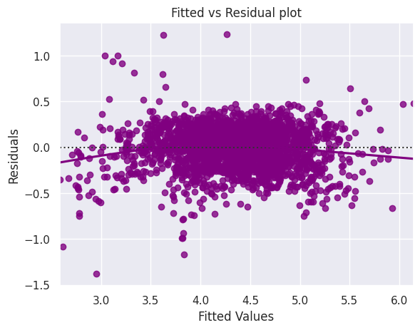

```python
sns.residplot(
    data=df_pred, x="Fitted Values", y="Residuals", color="purple", lowess=True
)
plt.xlabel("Fitted Values")
plt.ylabel("Residuals")
plt.title("Fitted vs Residual plot")
plt.show()
```

The scatter plot depicting the residuals (errors) against the fitted values (predicted values) has been examined. In the absence of any discernible pattern in this plot, we conclude that there are no signs of non-linearity in the data. The absence of a pattern implies that the model adequately captures linear effects, affirming the satisfaction of assumptions related to linearity and independence.

# Normality

Why the test?

Error terms, or residuals, should be normally distributed. If the error terms are not normally distributed, confidence intervals of the coefficient estimates may become too wide or narrow. Once confidence interval becomes unstable, it leads to difficulty in estimating coefficients based on minimization of least squares. Non-normality suggests that there are a few unusual data points that must be studied closely to make a better model. How to check normality?

The shape of the histogram of residuals can give an initial idea about the normality. It can also be checked via a Q-Q plot of residuals. If the residuals follow a normal distribution, they will make a straight line plot, otherwise not. Other tests to check for normality includes the Shapiro-Wilk test. Null hypothesis: Residuals are normally distributed Alternate hypothesis: Residuals are not normally distributed How to fix if this assumption is not followed?

We can apply transformations like log, exponential, arcsinh, etc. as per our data.

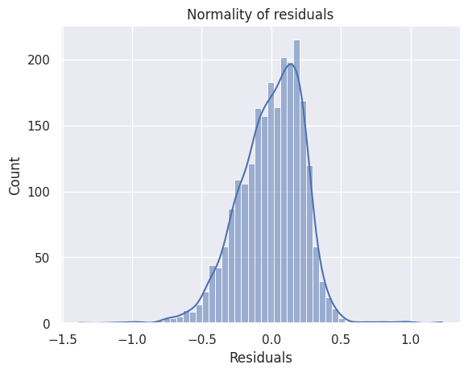

```python
sns.histplot(data=df_pred, x="Residuals", kde=True)
plt.title("Normality of residuals")
plt.show()
```

the histogram has an almost bell shape

lets look at the qq plot

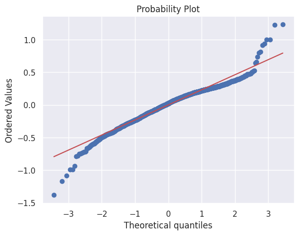

```python
import pylab
import scipy.stats as stats

stats.probplot(df_pred["Residuals"], dist="norm", plot=pylab)
plt.show()
```

The residuals more or less follow a straight line except for the tails.\ Let's check the results of the Shapiro-Wilk test.

```python
stats.shapiro(df_pred["Residuals"])
```

```
ShapiroResult(statistic=0.9697642922401428, pvalue=7.418283869630109e-22)
```

Since p-value < 0.05, the residuals are not normal as per the Shapiro-Wilk test Strictly speaking, the residuals are not normal However, as an approximation, we can accept this distribution as close to being normal So, the assumption is satisfied

# Heteroscedasticity test

Homoscedascity: If the variance of the residuals is symmetrically distributed across the regression line, then the data is said to be homoscedastic

Heteroscedascity: If the variance is unequal for the residuals across the regression line, then the data is said to be heteroscedastic

The presence of non-constant variance in the error terms results in heteroscedasticity. Generally, non-constant variance arises in presence of outliers

The residual vs fitted values plot can be looked at to check for homoscedasticity. In the case of heteroscedasticity, the residuals can form an arrow shape or any other non-symmetrical shape

The goldfeldquandt test can also be used. If we get a p-value > 0.05 we can say that the residuals are homoscedastic. Otherwise, they are heteroscedastic

Null hypothesis: Residuals are homoscedastic Alternate hypothesis: Residuals have heteroscedasticity

```python
import statsmodels.stats.api as sms
from statsmodels.compat import lzip

name = ["F statistic", "p-value"]
test = sms.het_goldfeldquandt(df_pred["Residuals"], x_train11)
lzip(name, test)
```

```
[('F statistic', 0.9975571583361194), ('p-value', 0.5166365631116148)]
```

Since p-value > 0.05, we can say that the residuals are homoscedastic. So, this assumption is satisfied